# Reproducible Research - Programming Assigment 1

Javier Saravia

9 de septiembre de 2016

## TOTAL NUMBER OF STEPS TAKEN BY DAY

### 1 Calculate the total number of steps taken per day

```
##  [1]   126 11352 12116 13294 15420 11015 12811  9900 10304 17382 12426
## [12] 15098 10139 15084 13452 10056 11829 10395  8821 13460  8918  8355
## [23]  2492  6778 10119 11458  5018  9819 15414 10600 10571 10439  8334
## [34] 12883  3219 12608 10765  7336    41  5441 14339 15110  8841  4472
## [45] 12787 20427 21194 14478 11834 11162 13646 10183  7047
```

### 2 Hist of total number of steps by day

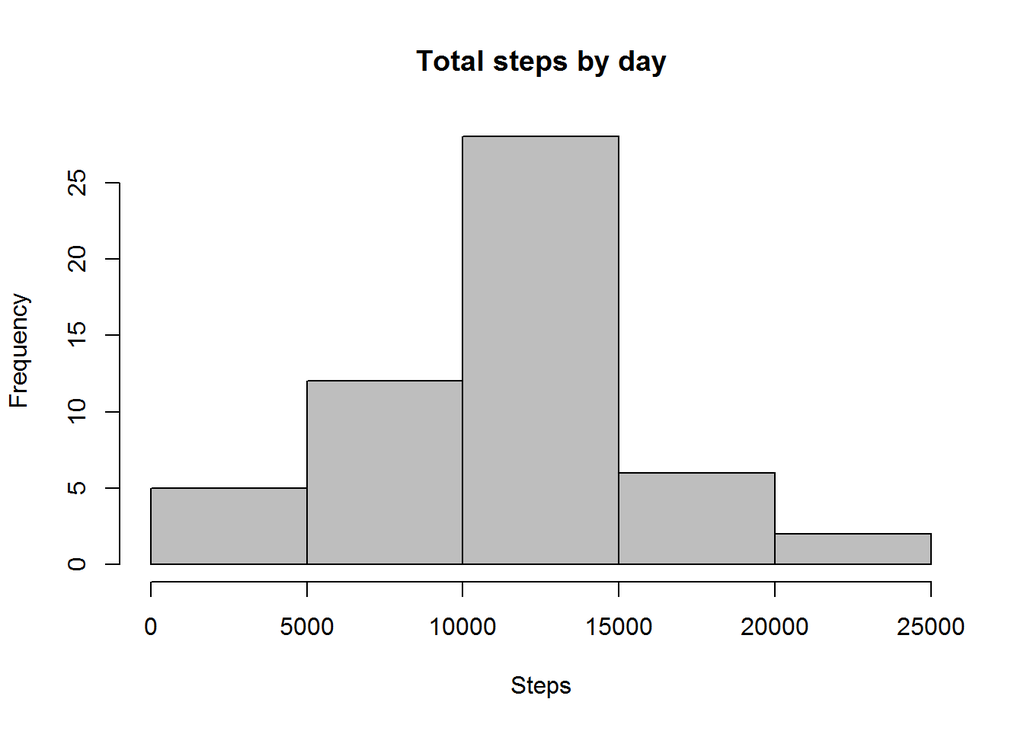

### 3 Mean and median of the steps taken by day

```
## [1] "The mean is 10766 and the median is 10765"
```

## WHAT IS THEAVERAGE DAILY ACTIVITY PATTERN?

```
##  [1]  0.44 39.42 42.07 46.16 53.54 38.25 44.48 34.38 35.78 60.35 43.15
## [12] 52.42 35.20 52.38 46.71 34.92 41.07 36.09 30.63 46.74 30.97 29.01
## [23]  8.65 23.53 35.14 39.78 17.42 34.09 53.52 36.81 36.70 36.25 28.94
## [34] 44.73 11.18 43.78 37.38 25.47  0.14 18.89 49.79 52.47 30.70 15.53
## [45] 44.40 70.93 73.59 50.27 41.09 38.76 47.38 35.36 24.47
```

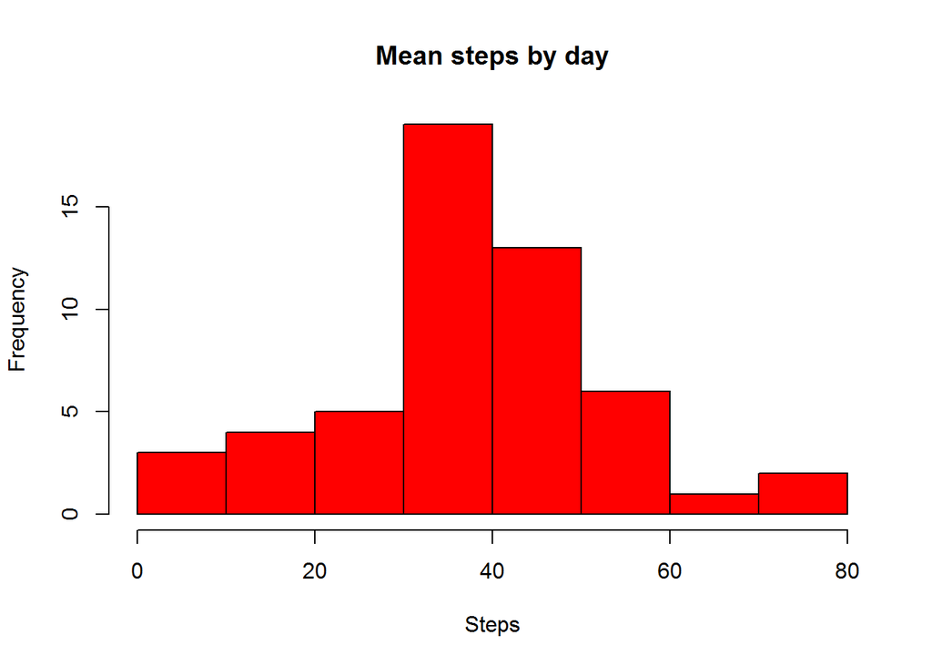

### 2 Which 5-minutes interval, on average across all days in the dataset, contains the maximun númber of steps?

```
##     interval interval_mean
## 104      835        206.17
## 105      840        195.92
## 107      850        183.40
## 106      845        179.57
## 103      830        177.30
## 101      820        171.15
```

## IMPUTING MISSING VALUES

### 1 Calculate and report the total number of missing values in the dataset

The NA values are in the STEPS Column

```
## [1] "Steps"
```

```
##
## FALSE  TRUE
## 15264  2304
```

```
## [1] "Date"
```

```
##
## FALSE
## 17568
```

```
## [1] "Interval"
```

```
##
## FALSE
## 17568
```

NA values can be removed by using COMPLETE.CASES function

The code used for remove NA values is: file2 <- file1[complete.cases(file1),]

```
## [1] "Rows before removing NA values:  17568"
```

```
## [1] "Rows after removing NA values:  15264"
```

### 2 Device a strategy for filling the NA values

The missing (NA) values will be filled by the interval mean using this code:

```
steps_na <- 1:17568

for(s in 1:17568)

if (is.na(file1$steps[s]))

  steps_na[s] = interval_steps2$interval_mean[interval_steps2$interval == file1$interval[s]]

else

  steps_na[s] = file1$steps[s]
```

The resulting vector (steps_na) does not have NA vales:

```
##
## FALSE
## 17568
```

### 3 Create a new dataset that is equal to the original data set but with the missing values filled in

The new dataset has the same number of rows of the original dataset. Demostration:

```
## [1] "Original dataset rows:  17568"
```

```
## [1] "New dataset rows:  17568"
```

The sum of steps by each days is:

[output not shown]

The histogram is:

[figure not shown]

## ARE THERE DIFFERENCES IN ACTIVITY PATTERNS BETWEEN WEEKDAYS AND WEEKENDS?

### 1 Create a new variable in the dataset that indicate when a date is weekday or weekend

The function WEEKDAYS() can be used for create a new column that contain a 1 when the date is a weekday and a 2 then the date is a weekend

The new vector cointain the following values:

```
## week_day
##     1     2
## 12960  4608
```

The new dataset is:

```
##   steps       date interval steps_na week_day
## 1    NA 2012-10-01        0     1.72        1
## 2    NA 2012-10-01        5     0.34        1
## 3    NA 2012-10-01       10     0.13        1
## 4    NA 2012-10-01       15     0.15        1
## 5    NA 2012-10-01       20     0.08        1
## 6    NA 2012-10-01       25     2.09        1
```

### 2 Plot of the average of steps by time interval and the average of steps by weekdays and weekends

The average of the steps by interval (using the last dataset created) only for weekdays is:

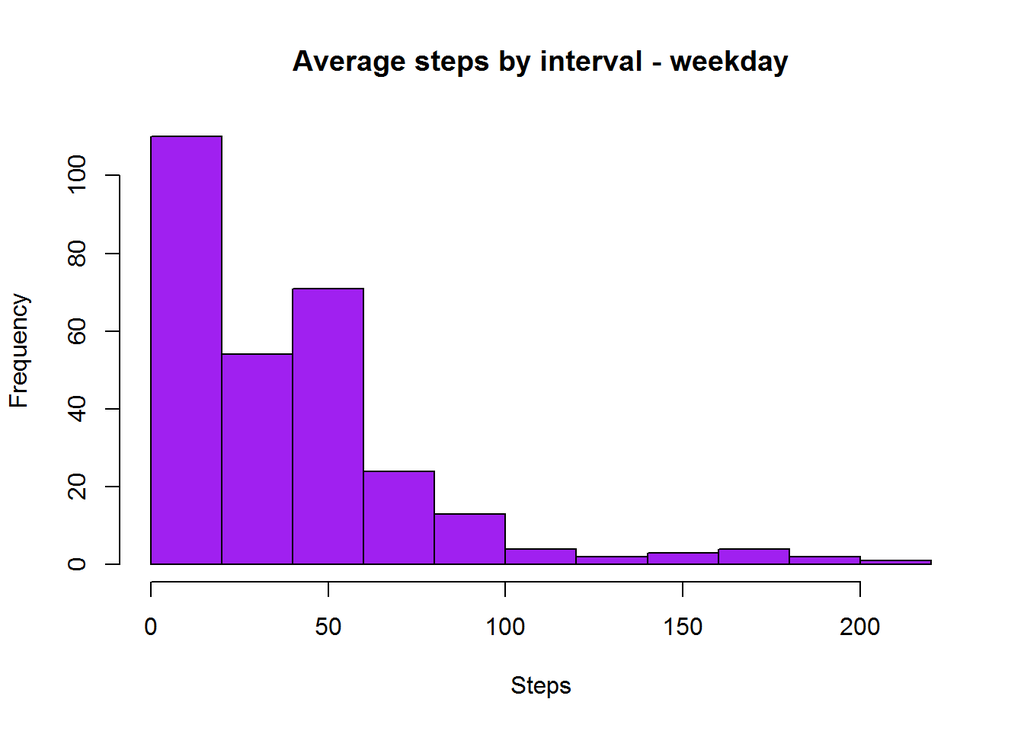

- ¡Is not possible to generate a hist of steps average by interval for weekends cause the generation of NA values!

### 3 Average of steps by interval for weekday and weekend

The average of steps for weekdays and weekends are:

```
## [1] "weekday steps average:  35.61"
```

```
## [1] "weekend steps average:  42.37"
```